# Phylogenetic Reconstruction of BP, TP and Wobbles

# Estimate the transition rates among discrete phenotypes using stochastic character mapping.

## Fit the models to the phylogenetic tree & select the best fitting model

We are going to select the model based on the lowest AIC value. The various models assume one rate for all transitions (ER), all different rates (forward and reverse) (ARD) or different rates for each transition but symmetrical (SYM).

```r
## fit ER model
fitER<-fitMk(ultrametric_rooted_tree,phenos,model="ER",pi="estimated")
```

```
Using pi estimated from the stationary distribution of Q assuming a flat prior.
pi =
      BP       TP   Wobble
0.333333 0.333333 0.333333
```

```r
## fit ARD model
fitARD<-fitMk(ultrametric_rooted_tree,phenos,model="ARD",pi="estimated")
```

```
Using pi estimated from the stationary distribution of Q assuming a flat prior.
pi =
      BP       TP   Wobble
0.130313 0.580528 0.289159
```

```r
## fit SYM model
fitSYM<-fitMk(ultrametric_rooted_tree,phenos,model="SYM",pi="estimated")
```

```
Using pi estimated from the stationary distribution of Q assuming a flat prior.
pi =
      BP       TP   Wobble
0.333333 0.333333 0.333333
```

```r
## extract AIC values for each model
aic<-c(AIC(fitER),AIC(fitARD),AIC(fitSYM))
## print summary table

model_summary<-data.frame(
  model=c("ER","ARD","Symmetric"),
  logL=c(logLik(fitER),logLik(fitARD),logLik(fitSYM)),
  AIC=aic,delta.AIC=aic-min(aic),
  weight=unclass(aic.w(aic)))

model_summary
```

| model | logL | AIC | delta.AIC | weight |
| --- | --- | --- | --- | --- |
| ER | -164.2070 | 330.4140 | 33.136060 | 5.602551e-08 |
| ARD | -142.6390 | 297.2780 | 0.000000 | 8.785971e-01 |
| Symmetric | -147.6182 | 301.2364 | 3.958424 | 1.214028e-01 |

For all trees, the “best” fit model is the ARD model. Let’s visualize the transition rates for the ARD model:

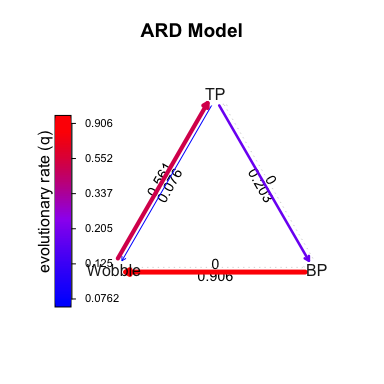

```r
  plot(fitARD, width=TRUE, color=TRUE, cex.rates=0.9, main="ARD Model") # Add a main title with the tree name
```

## Perform Stochastic Character Mapping

See Revell & Harmon (2022) “Comparative Phylogenetic Comparative Methods in R”, page 245.

```r
mtrees<-make.simmap(ultrametric_rooted_tree,phenos,model="ARD",nsim=1000,Q="mcmc",vQ=0.01, prior=list(use.empirical=TRUE),samplefreq=10)
```

```
Running MCMC burn-in. Please wait....
Running 10000 generations of MCMC, sampling every 10 generations.
Please wait....

make.simmap is simulating with a sample of Q from
the posterior distribution

Mean Q from the posterior is
Q =
                 BP           TP        Wobble
BP     -0.378386714  0.000000000  3.783867e-01
TP      0.007211466 -0.007211482  1.598389e-08
Wobble  0.000000000  0.005682601 -5.682601e-03
and (mean) root node prior probabilities
pi =
       BP        TP    Wobble
0.3333333 0.3333333 0.3333333
```

```
Done.
```

```r
pd<-summary(mtrees)
pd
```

```
1000 trees with a mapped discrete character with states:
 BP, TP, Wobble

trees have 44.706 changes between states on average

changes are of the following types:
     BP,TP BP,Wobble  TP,BP TP,Wobble Wobble,BP Wobble,TP
x->y     0    31.698 10.029     0.001         0     2.978

mean total time spent in each state is:
             BP         TP     Wobble    total
raw  33.0070152 38.2157019 6.63110030 77.85382
prop  0.4239614  0.4908648 0.08517373  1.00000
```

Let’s examine the distribution of changes that we see.

```r
dd<-density(mtrees)
dd
```

[output not shown]

We can look at these densities graphically as well…

```r
plot(dd,colors=c("orange","lightgreen","lightblue"),alpha=0.5)
```

[output not shown]

Here, we can illustrate the difference between a single tree…

```r
ss<-lapply(mtrees,summary)
head(ss,2)
```

[output not shown]

And all of the trees….

```r
all_trees<-as.data.frame(countSimmap(mtrees,c("BP","TP","Wobble")))

all_trees<-rownames_to_column(all_trees, "treeno")
all_trees<-all_trees %>% arrange(Tr.N)
head(all_trees)
```

[output not shown]

In this case, I’ve selected for the tree with the fewest overall number of changes in our nsim as the “base tree” and I’m going to plot the posterior densities onto the phylogenetic tree:

```r
pdf(file.path(root,'output_data/04_Phylogeny_And_Admixture/final_phylogeny.pdf'), width=1400/300, height=800/300)

par(oma=c(0,0.5,0.2,0)) # all sides have 3 lines of space
par(mar=c(0,0,0,0) + 0.1)
cols<-setNames(c("blue","red","purple"),levels(phenos))
library(geiger)
library(plotrix)

sodat<-treedata(ultrametric_rooted_tree, phenos, sort=TRUE, warnings=TRUE)
TipColors <- cols[match(sodat$data[,1], names(cols), nomatch=1)]

source(file.path(root,'code/04_Phylogeny_And_Admixture/customsimmap.R'))
source(file.path(root,'code/04_Phylogeny_And_Admixture/custom_pie.R'))

i<-1
customsimmap(mtrees[[40]],cols,ftype="off",type="fan",fsize=0.2,
    outline=TRUE,lwd=1,part=0.5,mar=c(0, 0,0, 0),ylim=c(-0.05,1.2))
customnodelabels(pie=pd$ace,piecol=cols, cex=0.25)
tiplabels(pch=21, col="black", bg = TipColors, cex=0.6,lwd=0.4)
arc.cladelabels(text="Bikagala",node=parent_nodes['BIK'],ln.offset=1.05,cex=0.2,
    lab.offset=1.07,mark.node=FALSE,orientation="horizontal")
arc.cladelabels(text="Bavavela",node=parent_nodes['BAV'],ln.offset=1.05,cex=0.2,
    lab.offset=1.07,mark.node=FALSE,orientation="horizontal")
arc.cladelabels(text="Douengi",node=parent_nodes['DOG'],ln.offset=1.05,cex=0.2,
    lab.offset=1.07,mark.node=FALSE,orientation="horizontal")
arc.cladelabels(text="Douvalou",node=parent_nodes['DOV'],ln.offset=1.06,cex=0.2,
    lab.offset=1.07,mark.node=FALSE,orientation="horizontal")
arc.cladelabels(text="Mouvanga",node=parent_nodes['MOV'],ln.offset=1.05,cex=0.2,
    lab.offset=1.07,mark.node=FALSE,orientation="horizontal")
arc.cladelabels(text="Bengue",node=parent_nodes['BEN'],ln.offset=1.05,cex=0.2,
    lab.offset=1.07,mark.node=FALSE,orientation="horizontal")
arc.cladelabels(text="Bambomo",node=parent_nodes['BAM'],ln.offset=1.05,cex=0.2,
    lab.offset=1.07,mark.node=FALSE,orientation="horizontal")
arc.cladelabels(text="Biroundou",node=parent_nodes['BIR'],ln.offset=1.05,cex=0.2,
    lab.offset=1.07,mark.node=FALSE,orientation="horizontal")
arc.cladelabels(text="PMAG",node=parent_nodes['PMAG_'],ln.offset=1.05,cex=0.2,
    lab.offset=1.07,mark.node=FALSE,orientation = "horizontal")
arc.cladelabels(text="PHOP",node=parent_nodes['PHOP_'],ln.offset=1.05,cex=0.2,
    lab.offset=1.07,mark.node=FALSE,orientation="horizontal")
arc.cladelabels(text="PGAB",node=parent_nodes['PGAB_'],ln.offset=1.05,cex=0.2,
    lab.offset=1.07,mark.node=FALSE,orientation="horizontal")
arc.cladelabels(text="PCUR",node=parent_nodes['PCUR_'],ln.offset=1.05,cex=0.2,
    lab.offset=1.07,mark.node=FALSE,orientation="horizontal")
arc.cladelabels(text="PPAR",node=parent_nodes['PPAR_'],ln.offset=1.05,cex=0.2,
    lab.offset=1.07,mark.node=FALSE,orientation="horizontal")
arc.cladelabels(text="Cocobeach",node=parent_nodes['COB'],ln.offset=1.05,cex=0.2,
    lab.offset=1.07,mark.node=FALSE,orientation="horizontal")
arc.cladelabels(text="Ipassa",node=getMRCA(ultrametric_rooted_tree,c("APA_6684","APA_193")),ln.offset=1.05,cex=0.2,
    lab.offset=1.07,mark.node=FALSE,orientation="horizontal")
arc.cladelabels(text="Balé",node=getMRCA(ultrametric_rooted_tree,c("IVI_4832","IVI_4897")),ln.offset=1.05,cex=0.2,
    lab.offset=1.07,mark.node=FALSE,orientation="horizontal")
arc.cladelabels(text="PSZA",node=getMRCA(ultrametric_rooted_tree,c("PSZA_456","PSZA_450")),ln.offset=1.05,cex=0.2,
    lab.offset=1.07,mark.node=FALSE, orientation="horizontal")
legend("topleft",c(levels(phenos)),
    pch=15,col=c(col.pheno),
    pt.cex=.9,cex=0.4,bty="n")
add.scale.bar(cex = 0.4, length=0.1)
dev.off()
```